# Midterm II Winter 2020 Key

Data Science for Managers

Due by class: 3/30/2020

Submit a RMarkdown file for the following five problems. You will need the tidyverse, nycflights13, and lubridate libraries to in order for your code to work.

## Problem #1

Create a boxplot that compares highway and city mileage using the data from the mpg tibble.

- Create a long tibble
- Create a boxplot that orders the boxes for each type of mileage (which is a factor) by the IQR of mileage. Put highway lowest on the graph.
- Label your graph to match the example

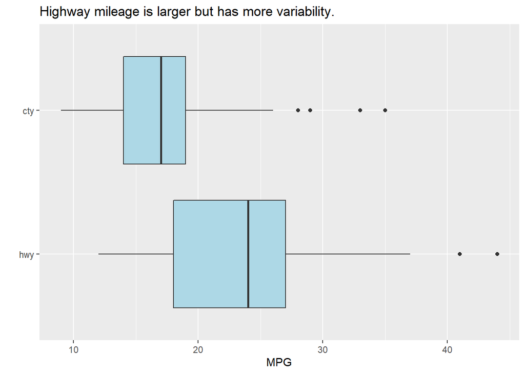

```r
mpg %>%
  select(hwy, cty) %>%
  gather(key = "type_of_driving", value = "MPG") %>%
    ggplot(aes(x = MPG, y = fct_reorder(type_of_driving, MPG, IQR) %>% fct_rev())) +
    geom_boxplot(fill = "lightblue") +
  labs(
    title = "Highway mileage is larger but has more variability.",
    y = ""
  )
```

## Problem #2

Show that you can get the same results using map and a for loop. For the faithful tibble (variables: eruptions and waiting), calculate the means using

- the appropriate map function
- a for loop that uses all three parts of a loop
- print out the results of your loop

### Results of the map

```r
## Map
faithful %>% map_dbl(mean)
```

```
## eruptions   waiting
##  3.487783 70.897059
```

### Results of for loop

```r
## For loop
Means <- vector("double", length(faithful))
for(i in seq_along(faithful)){
  Means[[i]] <- mean(faithful[[i]])
}
# Print out the result
Means
```

```
## [1]  3.487783 70.897059
```

## Problem #3

Count the number of non-canceled flights leaving from the three New York City airports and create a table that includes the full name of the airport from the FAA information in the airports tibble.

- Exclude all the flights that never departed from the flights tibble
- Count the number of flights
- Append information from the airports tibble using an appropriate join

```r
flights %>%
  filter(!is.na(dep_time)) %>%
  count(origin) %>%
  left_join(airports, by = c("origin" = "faa")) %>%
  select(name, n)
```

```
## # A tibble: 3 x 2
##   name                     n
##   <chr>                <int>
## 1 Newark Liberty Intl 117596
## 2 John F Kennedy Intl 109416
## 3 La Guardia          101509
```

## Problem #4

Write a function that receives a date as an argument and then returns the day of the week as a literal value. For example, your own function day_of_week(20200325) returns “Wed”.

- Convert your argument into a date
- Find the day of the week using a function from lubridate.

```r
day_of_week <- function(date){
  date = ymd(date)
  wday(date, label = TRUE)
}
day_of_week(20200325)
```

```
## [1] Wed
## Levels: Sun < Mon < Tue < Wed < Thu < Fri < Sat
```

## Problem #5

Use the mutate and cut functions to create a factor or categorical variable from the highway mileage (hwy) that has three different categories. They are:

- good (0-18]
- better (18-27]
- best (27-35]

The interval notation (0-18] includes the values 0 thru 18. If the value exactly equals 18, then it is included in this interval rather than (18, 27].

Only print out two columns, the hwy column and your new variable.

```r
mpg %>%
  mutate(hwy_class = cut(
    hwy,
    breaks = c(0, 18, 27, 35),
    labels = c("good", "better", "best")
  )) %>%
  select(hwy, hwy_class)
```

```
## # A tibble: 234 x 2
##      hwy hwy_class
##    <int> <fct>
##  1    29 best
##  2    29 best
##  3    31 best
##  4    30 best
##  5    26 better
##  6    26 better
##  7    27 better
##  8    26 better
##  9    25 better
## 10    28 best
## # ... with 224 more rows
```